# Práctica 9: Reconstrucción filogenética

Última actualización:

15 de mayo de 2026

## DATOS

Cargamos los datos del alineamiento de los cromosomas mitocondriales de gorila, chimpancé, bonobo, *Homo heidelbergensis*, humanos denisovanos, humanos neandertales y humanos modernos:

```r
library(phangorn)
mtdna <- read.phyDat('../../data/2026-03-31/mtDNA.fasta', format = 'fasta')
```

```r
library(Biostrings)
as.StringSet(mtdna)
```

```
DNAStringSet object of length 42:
     width seq                                              names
 [1] 16603 GATTACACATGCAAGCATCCCCG...CCTTTCTATTAACTCTTAGTAG G.gorilla_D38114
 [2] 16603 GATTACACATGCAAGCATCCCCG...CCTTTCTATTAGCTCTTAGTAA P.troglodytes_JF7...
 [3] 16603 GATTACACATGCAAGCATCCCCG...CCTTTCTATTAGCCCTTAGTAA P.troglodytes_JN1...
 [4] 16603 GATTACACATGCAAGCATCCCCG...CCTTTCTATTAGCCCTTAGTAA P.troglodytes_JF7...
 [5] 16603 GATTACACATGCAAGCATCCCCG...CCTTTCTATTAGCCCTTAGTAA P.troglodytes_HM0...
 ...   ... ...
[38] 16603 GATTACACATGCAAGCATCCCCG...CCTTTCTATTAGCTCTTAGTAA H.s.modern_DQ779932
[39] 16603 GATTACACATGCAAGCATCCCCG...CCTTTCTATTAGCTCTTAGTAA H.s.modern_AP008640
[40] 16603 GATTACACATGCAAGCATCCCCG...CCTTTCTATTAGCTCTTAGTAA H.s.modern_AY495317
[41] 16603 GATTACACATGCAAGCATCCCCG...CCTTTCTATTAGCTCTTAGTAA H.s.modern_J01415
[42] 16603 GATTACACATGCAAGCATCCCCG...CCTTTCTATTAGCTCTTAGTAA H.s.modern_FJ236981
```

**ImportanteEjercicio**

¿Puedes confirmar el número de secuencias? ¿Qué longitud tiene el alineamiento? ¿Qué función usarías para extraer los nombres de las secuencias?

La lista tiene una longitud de 42, es decir, contiene 42 secuencias. El alineamiento tiene una longitud de 16603 pb. Con `names(mtdna)` podemos extraer los nombres de las secuencias y la especie de la que se han obtenido.

## ÁRBOLES BASADOS EN DISTANCIAS

Para obtener árboles filogenéticos como NJ o UPGMA, que están basados en distancias, necesitamos calcular previamente las distancias entre las secuencias:

```r
distancias <- dist.ml(mtdna, model = 'F81')
mt_nj    <- NJ(distancias)
mt_upgma <- upgma(distancias)
```

**NotaEjercicio**

- ¿De qué clase son los objetos `mt_nj` y `mt_upgma`?

  Son listas de 4 elementos.
- Consulta la estructura de estos objetos (`str(mt_nj)`).

  ```r
  str(mt_nj)
  ```

  ```
  List of 4
   $ edge       : int [1:81, 1:2] 44 44 54 54 53 53 52 52 51 51 ...
   $ edge.length: num [1:81] 1.97e-04 2.26e-04 -4.37e-08 4.37e-08 8.51e-08 ...
   $ tip.label  : chr [1:42] "G.gorilla_D38114" "P.troglodytes_JF727212" "P.troglodytes_JN191207" "P.troglodytes_JF727168" ...
   $ Nnode      : int 40
   - attr(*, "class")= chr "phylo"
   - attr(*, "order")= chr "postorder"
  ```

  ```r
  str(mt_upgma)
  ```

  ```
  List of 4
   $ edge       : int [1:82, 1:2] 63 63 49 49 48 48 59 59 55 55 ...
   $ edge.length: num [1:82] 0.00127 0.00127 0.001422 0.000151 0.011063 ...
   $ tip.label  : chr [1:42] "G.gorilla_D38114" "P.troglodytes_JF727212" "P.troglodytes_JN191207" "P.troglodytes_JF727168" ...
   $ Nnode      : int 41
   - attr(*, "class")= chr "phylo"
   - attr(*, "order")= chr "postorder"
  ```

- Represéntalos gráficamente (`plot(mt_nj)`) y consulta la ayuda de la función `plot.phylo()` para saber qué opciones de representación gráfica tienes.

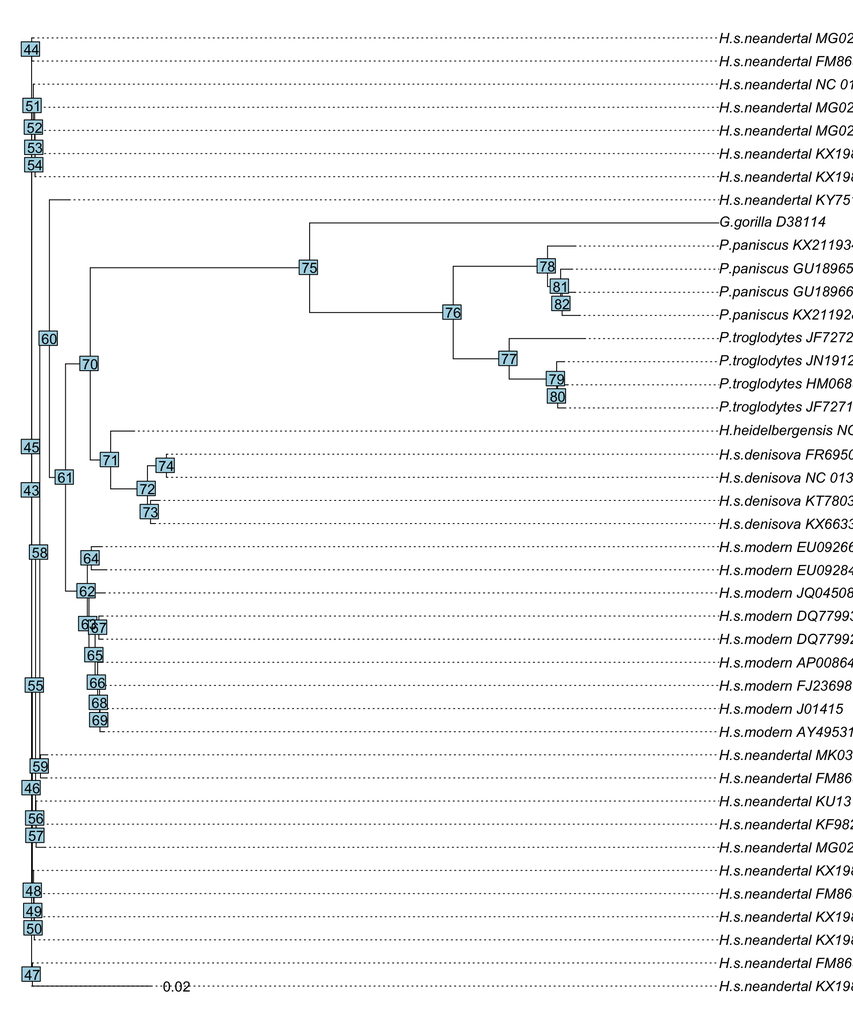

  ```r
  plot(mt_nj, align.tip.label = TRUE, no.margin = TRUE)
  add.scale.bar()
  nodelabels()
  ```

- Para qué sirven las funciones `add.scale.bar()` y `axisPhylo()`?

  La función `add.scale.bar()` indica la cantidad de cambio evolutivo (distancia genética), es decir, nos ayuda a entender cuanto difieren las secuencias.

  La función `axisPhylo()` añade un eje con escala numérica al árbol mostrando los calores acumulados de distancia desde la raíz.

## ENRAIZAR

### Escogiendo el nodo

Para enraizar el árbol con la función `root()` debemos especificar, en este caso, el nodo interno en el que situar la raíz. El nodo 75 parece ser el ancestro entre gorilas y chimpancés, y por tanto, también de humanos, por lo que lo designamos como raíz.

```r
mt_nj_rooted <- root(mt_nj, node = 75)
```

### Con un outgrup

También se puede enraizar el árbol especificando el *outgroup*, ya que al hacerlo el número de los nodos puede cambiar, por lo que es más seguro hacerlo utilizando el nombre.

```r
# Debería dar el mismo resultado:
mt_nj_rooted <- root(mt_nj, outgroup = 'G.gorilla_D38114')
```

### En el punto medio

Con la función `midpoint()` se puede obtener un árbol más equilibrado y con las puntas alineadas.

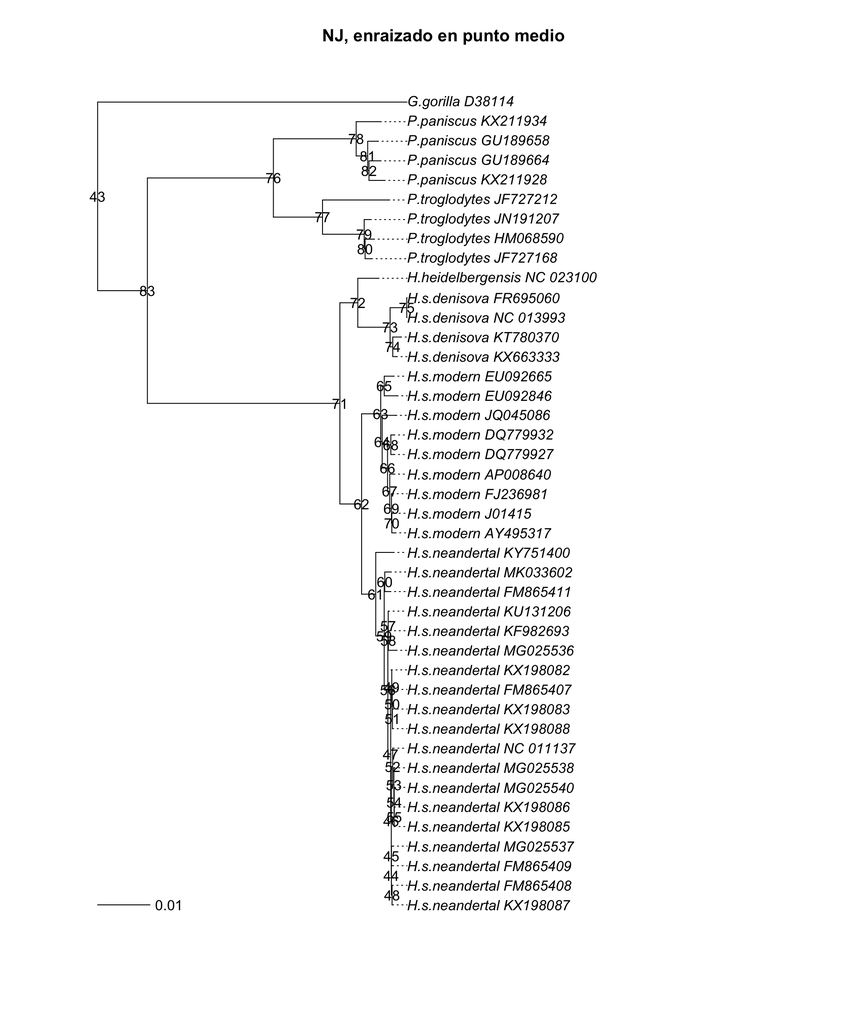

```r
# Esto sobreescribe el objeto anterior:
mt_nj_rooted <- midpoint(mt_nj)
plot(mt_nj_rooted, align.tip.label = TRUE, main = 'NJ, enraizado en punto medio')
nodelabels(frame = 'none')
add.scale.bar()
```

### Con datación de hojas

El problema con `midpoint()` es que asume que todas las ramas son contemporáneas, que no es nuestro caso. Conociendo las edades estimadas de las secuencias podemos aplicar el método de enraizado *root-to-tip* con la función `rtt()`. Para ello necesitamos crear un vector con las edades de las ramas y asignarlas con `mt_nj$tip.label`.

```r
fechas <- c(0, 0, 0, 0, 0, 0, 0, 0, 0,
            -400000,
            -39000, -50000, -110000, -110000,
            -39820, -40096, -38515, -38310, -39000, -40000, -41210,
            -42430, -42540, -43230, -43780, -44290, -44770, -49000,
            -50000, -82752, -65000, -122287, -110450,
            0, 0, 0, 0, 0, 0, 0, 0, 0)
# Observa que hay que asignar el resultado de setNames() a "fechas"
fechas <- setNames(fechas, mt_nj$tip.label)
fechas
```

```
           G.gorilla_D38114      P.troglodytes_JF727212
                          0                           0
     P.troglodytes_JN191207      P.troglodytes_JF727168
                          0                           0
     P.troglodytes_HM068590         P.paniscus_KX211934
                          0                           0
        P.paniscus_KX211928         P.paniscus_GU189658
                          0                           0
        P.paniscus_GU189664 H.heidelbergensis_NC_023100
                          0                     -400000
     H.s.denisova_NC_013993       H.s.denisova_FR695060
                     -39000                      -50000
      H.s.denisova_KX663333       H.s.denisova_KT780370
                    -110000                     -110000
    H.s.neandertal_KX198085     H.s.neandertal_KX198086
                     -39820                      -40096
    H.s.neandertal_MG025538    H.s.neandertal_NC_011137
                     -38515                      -38310
    H.s.neandertal_FM865409     H.s.neandertal_FM865407
                     -39000                      -40000
    H.s.neandertal_KX198088     H.s.neandertal_KX198083
                     -41210                      -42430
    H.s.neandertal_MG025540     H.s.neandertal_MG025536
                     -42540                      -43230
    H.s.neandertal_MG025537     H.s.neandertal_KX198087
                     -43780                      -44290
    H.s.neandertal_KX198082     H.s.neandertal_FM865408
                     -44770                      -49000
    H.s.neandertal_KU131206     H.s.neandertal_KF982693
                     -50000                      -82752
    H.s.neandertal_FM865411     H.s.neandertal_KY751400
                     -65000                     -122287
    H.s.neandertal_MK033602         H.s.modern_EU092846
                    -110450                           0
        H.s.modern_EU092665         H.s.modern_JQ045086
                          0                           0
        H.s.modern_DQ779927         H.s.modern_DQ779932
                          0                           0
        H.s.modern_AP008640         H.s.modern_AY495317
                          0                           0
          H.s.modern_J01415         H.s.modern_FJ236981
                          0                           0
```

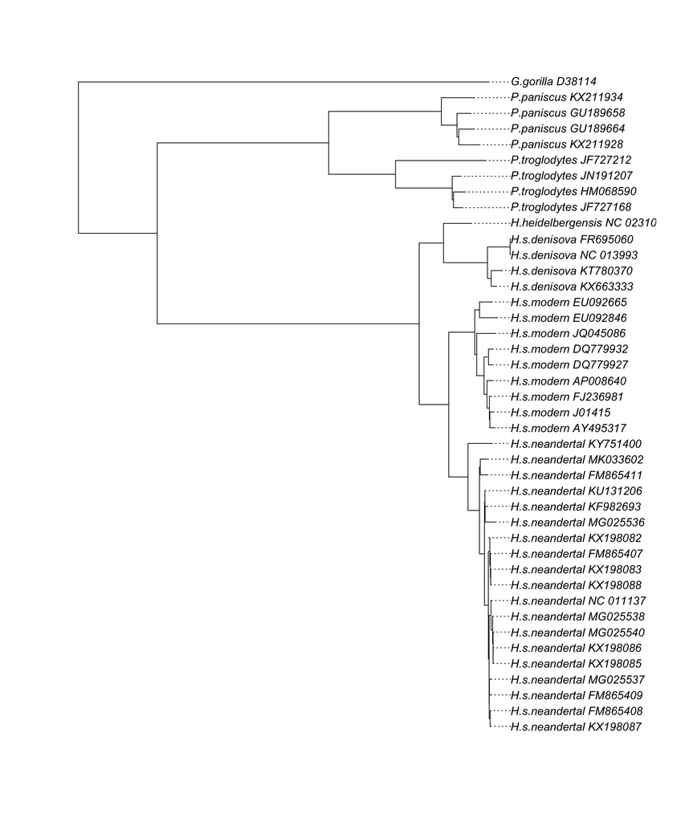

```r
mt_nj_rtt <- rtt(mt_nj, tip.dates = fechas, objective = 'rms')
plot(mt_nj_rtt, align.tip.label = TRUE)
```

**NotaEjercicio**

- ¿Se corresponden bien las distancias evolutivas estimadas con las dataciones?

  No. Hay ramas que han acumulado cambios que deberían haber quedado más atrás.
- ¿Qué secuencias crees que se ajustan menos a su supuesta edad?

  Los denisovanos deberían haber dejado de acumular amutaciones hace mucha más tiempo.
- ¿Qué razones puede haber para que la edad de una secuencia no se corresponda con la cantidad de cambios que ha acumulado?

  Podemos asumir que las dataciones moleculares no son fiables o que las muestras arqueológicas tengan errores. También es posible que el método estadistico usado para corregir los errores de la datación no haya sido bueno en algunas muestras, lo que genera que las ramas se alarguen más de lo que es realista.

## DISTANCIAS

Con el objeto `distancias` que habíamos creado antes se puede estimar la cantidad de cambios entre los cromosomas de un grupo y otro, y con esto podemos calcular la distancia entre, por ejemplo, humanos y neandertales.

```r
distMat <- as.matrix(distancias)
# Esto son vectores lógicos que podemos usar después para seleccionar filas
# y columnas de la matriz de distancias.
modernos     <- startsWith(colnames(distMat), 'H.s.modern')
neandertales <- startsWith(colnames(distMat), 'H.s.neandertal')
denisovanos  <- startsWith(colnames(distMat), 'H.s.denisova')
chimpances   <- startsWith(colnames(distMat), 'P.troglodytes')
bonobos      <- startsWith(colnames(distMat), 'P.paniscus')
mean(distMat[modernos, neandertales])
```

```
[1] 0.01214282
```

**NotaEjercicio**

- Calcula las distancias medias entre todos los grupos.

  ```r
  mean(distMat[modernos, neandertales])
  ```

  ```
  [1] 0.01214282
  ```

  ```r
  mean(distMat[modernos, denisovanos])
  ```

  ```
  [1] 0.02250501
  ```

  ```r
  mean(distMat[modernos, chimpances])
  ```

  ```
  [1] 0.09104153
  ```

  ```r
  mean(distMat[modernos, bonobos])
  ```

  ```
  [1] 0.09239182
  ```

  ```r
  mean(distMat[neandertales, denisovanos])
  ```

  ```
  [1] 0.02201398
  ```

  ```r
  mean(distMat[neandertales, chimpances])
  ```

  ```
  [1] 0.09041225
  ```

  ```r
  mean(distMat[neandertales, bonobos])
  ```

  ```
  [1] 0.09089352
  ```

  ```r
  mean(distMat[denisovanos, chimpances])
  ```

  ```
  [1] 0.09129525
  ```

  ```r
  mean(distMat[denisovanos, bonobos])
  ```

  ```
  [1] 0.09297814
  ```

  ```r
  mean(distMat[chimpances, bonobos])
  ```

  ```
  [1] 0.04059035
  ```

- ¿Cuántas veces mayor es la distancia entre humanos y chimpancés que entre humanos y neandertales?

  ```r
  mean(distMat[modernos, chimpances]) / mean(distMat[modernos, neandertales])
  ```

  ```
  [1] 7.497561
  ```

  La distancia entre humanos y chimpancés es 7,49 veces mayor que la distancia entre humanos y neandertales.
- ¿Cómo calcularías la distancia media entre dos secuencias de humanos modernos?

  ```r
  # La submatriz siguiente contiene ceros en la diagonal. Si queremos excluir
  # del cálculo de la media las distancias entre cada secuencia consigo misma,
  # habrá que tenerlo en cuenta:
  distMat[modernos, modernos]
  ```

  ```
                      H.s.modern_EU092846 H.s.modern_EU092665 H.s.modern_JQ045086
  H.s.modern_EU092846         0.000000000         0.004115877         0.005454272
  H.s.modern_EU092665         0.004115877         0.000000000         0.005393179
  H.s.modern_JQ045086         0.005454272         0.005393179         0.000000000
  H.s.modern_DQ779927         0.005392590         0.005270729         0.004724566
  H.s.modern_DQ779932         0.005513658         0.005391783         0.004906390
  H.s.modern_AP008640         0.005517618         0.005152317         0.004787395
  H.s.modern_AY495317         0.005635614         0.005148861         0.004784781
  H.s.modern_J01415           0.005453806         0.005210372         0.004785411
  H.s.modern_FJ236981         0.005331436         0.004966433         0.004481205
                      H.s.modern_DQ779927 H.s.modern_DQ779932 H.s.modern_AP008640
  H.s.modern_EU092846         0.005392590         0.005513658         0.005517618
  H.s.modern_EU092665         0.005270729         0.005391783         0.005152317
  H.s.modern_JQ045086         0.004724566         0.004906390         0.004787395
  H.s.modern_DQ779927         0.000000000         0.001087163         0.002359394
  H.s.modern_DQ779932         0.001087163         0.000000000         0.002298600
  H.s.modern_AP008640         0.002359394         0.002298600         0.000000000
  H.s.modern_AY495317         0.002478978         0.002660427         0.001692960
  H.s.modern_J01415           0.002418729         0.002600192         0.001693182
  H.s.modern_FJ236981         0.002055212         0.002236605         0.001269395
                      H.s.modern_AY495317 H.s.modern_J01415 H.s.modern_FJ236981
  H.s.modern_EU092846         0.005635614      0.0054538063        0.0053314359
  H.s.modern_EU092665         0.005148861      0.0052103722        0.0049664328
  H.s.modern_JQ045086         0.004784781      0.0047854113        0.0044812052
  H.s.modern_DQ779927         0.002478978      0.0024187289        0.0020552122
  H.s.modern_DQ779932         0.002660427      0.0026001920        0.0022366046
  H.s.modern_AP008640         0.001692960      0.0016931824        0.0012693954
  H.s.modern_AY495317         0.000000000      0.0010873068        0.0009058850
  H.s.modern_J01415           0.001087307      0.0000000000        0.0006642889
  H.s.modern_FJ236981         0.000905885      0.0006642889        0.0000000000
  ```

  ```r
  # Por ejemplo:
  z <- distMat[modernos, modernos]
  z[z == 0] <- NA
  mean(z, na.rm = TRUE)
  ```

  ```
  [1] 0.003747961
  ```

En los árboles las distancias se representan mediante la suma de las longitudes que separan las hojas, y se puede obtener con la función `cophenetic()`.

```r
distCofen <- cophenetic(mt_nj_rooted)
```

**NotaEjercicio**

¿Cuánto se parecen las distancias estimadas a las distancias cofenéticas?

Al ver una relación lineal entre los puntos y que están en la recta x = y podemos concluir que los valores de ambas matrices son prácticamente idénticos.

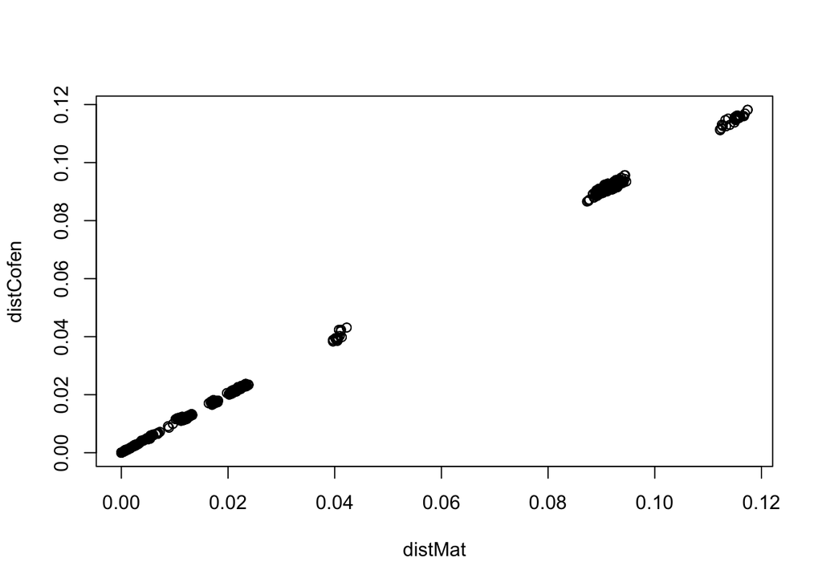

```r
plot(distMat, distCofen)
```

## LIMPIEZA O FILTRADO DEL ALINEAMIENTO

Las distancias crudas informan de la presencia de pares de secuencias idénticas, pero pueden dar problemas con algunos métodos.

```r
crudas <- dist.dna(as.DNAbin(mtdna), model = 'raw')
crudas <- as.matrix(crudas)
identicas <- which(crudas == 0 & lower.tri(crudas), arr.ind = TRUE)
# posiciones de la semimatriz inferior donde las distancias son 0:
identicas
```

```
                        row col
H.s.neandertal_KX198086  16  15
H.s.neandertal_MG025540  23  15
H.s.neandertal_MG025540  23  16
H.s.neandertal_KX198088  21  20
H.s.neandertal_KX198083  22  20
H.s.neandertal_KX198082  27  20
H.s.neandertal_KX198083  22  21
H.s.neandertal_KX198082  27  21
H.s.neandertal_KX198082  27  22
```

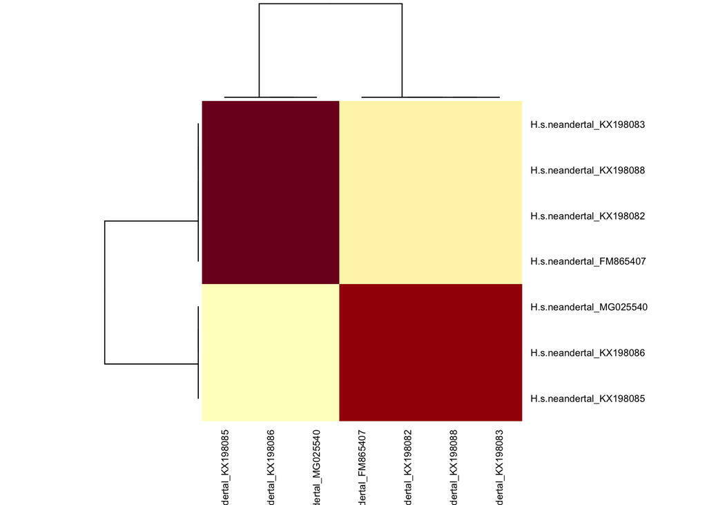

```r
repetidas <- unique(c(identicas[, 'row'], identicas[, 'col']))
heatmap(crudas[repetidas, repetidas], cexRow = 0.7, cexCol = 0.7)
```

Las secuencias de Neandertales KX198085, KX198086 y MG025540 son idénticas entre ellas, y las FM865407, KX198082, KX198088 y KX198083 también, por lo que vamos a dejar solo una de cada grupo: MG025540 y FM865407.

```r
# La exclamación ("!") invierte el valor lógico de lo que la sigue.
# La función "grepl()" produce un vector lógico con "TRUE" donde los nombres
# de las secuencias contienen alguna de esas palabras.
mtdna37 <- mtdna[! grepl('(KX198085|KX198086|KX198082|KX198088|KX198083)',
                         names(mtdna)), ]
mtdna37
```

```
37 sequences with 16603 character and 974 different site patterns.
The states are a c g t
```

**NotaEjercicio**

¿Serías capaz de crear otro conjunto de datos, `mtdna28`, que sólo contenga secuencias del género *Homo*?

Partimos de mtdna 37 porque así no hay datos duplicados de neandertal

```r
mtdna28 <- mtdna37[grepl('^H.',
                         names(mtdna37)), ]
```

También podemos eliminar la secuencia de gorila, que es muy divergente y puede haber evolucionado a un ritmo diferente:

```r
mtdna36 <- mtdna37[! startsWith(names(mtdna37), 'G.gorilla'),]
```